# R Package imputeTestbench to Compare Imputation Methods for Univariate Time Series

Marcus W Beck

USEPA National Health and Environmental Effects Research Laboratory, Gulf Ecology Division

Neeraj Bokde

Visvesvaraya National Institute of Technology, Nagpur

Gualberto Asencio-Cortés

Universidad Pablo de Olavide

Kishore Kulat

Visvesvaraya National Institute of Technology, Nagpur

2018-05-21

Abstract

Missing observations are common in time series data and several methods are available to impute these values prior to analysis. Variation in statistical characteristics of univariate time series can have a profound effect on characteristics of missing observations and, therefore, the accuracy of different imputation methods. The *imputeTestbench* package can be used to compare the prediction accuracy of different methods as related to the amount and type of missing data for a user-supplied dataset. Missing data are simulated by removing observations completely at random or in blocks of different sizes depending on characteristics of the data. Several imputation algorithms are included with the package that vary from simple replacement with means to more complex interpolation methods. The testbench is not limited to the default functions and users can add or remove methods as needed. Plotting functions also allow comparative visualization of the behavior and effectiveness of different algorithms. We present example applications that demonstrate how the package can be used to understand differences in prediction accuracy between methods as affected by characteristics of a dataset and the nature of missing data.

# Introduction

Univariate time series data provide valuable information that forms the basis of analysis across several disciplines. The most notable characteristic of time series data is time-dependent correlations between observations such that the likelihood of observing a single value depends on the values of past or future observations (Shumway and Stoffer 2011; Box et al. 2015). This precludes the use of most conventional statistical methods that require independence of observations as a fundamental assumption prior to analysis. However, unique methods have been developed that account for and leverage the statistical characteristics of time series data to provide insight beyond those provided by more conventional techniques. For example, additive or multiplicative models can be used to separate a univariate time series data into unique components with different structures (e.g., Gould et al. 2008), whereas multiple methods for signal processing seek to isolate dominant components that are independent of random variation in the observed data (e.g., Mendel 2000).

Many analysis methods for time series require complete observations at each time step across the period of interest. Complete datasets rarely exist such that missing observations are often defining characteristics of time series data (e.g., Gomez and Maravall 1994; Honaker and King 2010). Missing observations can occur for several reasons, although the type and amount of missing values depend on characteristics of the data (Schafer 1997; Schafer and Graham 2002). For example, a time series with no serial dependence between observations is more likely to have missing observations that are completely random (Rubin 1976). A more common scenario for time series data is missing observations in ‘chunks’ or data missing in sequence for a period of time (Schafer 1997; Donders et al. 2006). The occurrence of missing chunks relates directly to the correlation structure of time series data, as in cases when experiments are not continuously maintained, remote data fail to transmit from the source to the user, or funding mechanisms for monitoring programs are discontinuous. As such, the accuracy of imputation methods can vary considerably depending on characteristics of the dataset (Yozgatligil et al. 2013). Similar to the application of analysis methods that use time-dependent information, imputation methods must also faithfully reconstruct missing observations in this context.

Identifying an appropriate imputation method is often the first step towards more formal time series analysis. Different imputation methods will have differing precision in reproducing missing values, where precision will depend on how much data are missing and how the data are missing (i.e., individual observations missing at random or data missing in continuous chunks). The characteristics of the dataset will also influence imputation precision between methods. An expectation is that imputation methods that leverage characteristics of the dataset to predict missing values will perform better than more naïve methods, if indeed there is sufficient temporal structure. Accordingly, choosing an appropriate imputation method can be facilitated by using a standardized method of comparison. A simple approach for method comparison is to evaluate prediction accuracy from imputed values after removing observations from a test dataset, where the test dataset should have characteristics similar to the one requiring imputation. For example, (Zhu et al. 2011) proposed a kernel-based iterative estimation method for missing data and compared the approach to other conventional frequency estimators. The methods were compared by simulating different amounts of missing data, predicting the missing values with each method, and then comparing the predictions to the actual data that were removed. Table 1 reproduces the results, where the rows show root-mean squared error (*RMSE*) between observed and predicted data for each imputation method after removing and predicting 10% and 80% of the complete dataset. Additional studies have used a similar workflow to compare the performance of imputation methods (Jörnsten, Ouyang, and Wang 2007; Li et al. 2015; Nguyen, Carlin, and Lee 2013; Ran et al. 2015; Tak, Woo, and Yeo 2016).

Table 1: An approach for comparing imputation methods. Methods in the left column are compared by varying the amount of missing data (10% and 80%) in a complete dataset and number of iterations (*T*) for which the missing data are removed at random. *V* is the mean *RMSE* of the imputed values. Reproduced from (Zhu et al. 2011).

|  | **10%** |  | **80%** |  |
| --- | --- | --- | --- | --- |
| Method names | *T* | *V* | *T* | *V* |
| Mixing | 8 | 0.085 | 20 | 1.53 |
| Poly | 10 | 0.103 | 25 | 2.11 |
| RBF | 11 | 0.107 | 29 | 2.86 |
| Normal | 14 | 0.121 | 30 | 3.01 |
| FE | 13 | 0.117 | 29 | 2.59 |

There are several challenges for adopting a standardized approach to compare imputation methods. An obvious concern is the amount of missing data, such that a complete gradient from very few to many observations should be evaluated with each method (Zhu et al. 2011). For example, one method may be superior for very few missing observations but perform poorly relative to other methods for many missing observations. Additionally, missing data as random or in chunks could also influence the comparisons of prediction accuracy depending on the dataset (Donders et al. 2006). Interpretations may also be influenced by the choice of error metric (e.g., *RMSE*) as different metrics have different objectives (Yozgatligil et al. 2013).

This paper describes the [*imputeTestbench*](https://CRAN.R-project.org/package=imputeTestbench) package to simultaneously compare different imputation methods for univariate time series (Bokde and Beck 2017). The goal of this package is to provide an evaluation toolset that addresses the above challenges for identifying an appropriate imputation method before more detailed analysis. This package provides several options for simulating missing observations with repeated sampling from a complete dataset. Missing values are imputed using any of several methods and then compared with a common error metric chosen by the user. Plotting functions are available to visualize the simulation methods for missing data, the predicted time series from each method, and overall evaluation of prediction accuracy between methods. Example applications are provided to demonstrate how *imputeTestbench* can be used to understand why different methods have different prediction accuracy given characteristics of the original data and characteristics of the missing data.

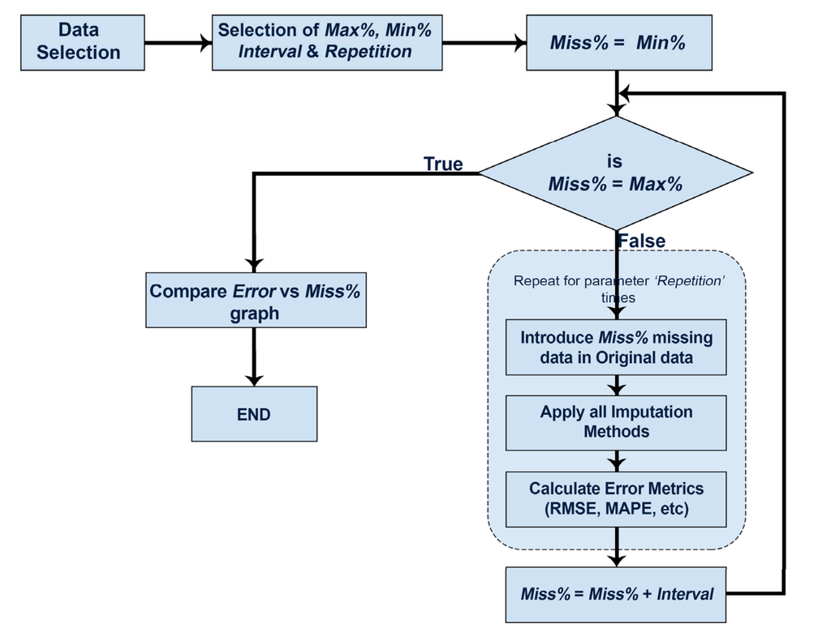

Figure 1: Workflow diagram for comparing imputation methods. *Min*% and *Max*% are minimum and maximum percent of missing values in the dataset. Details are described below.

# Overview of *imputeTestbench*

The theoretical foundation of *imputeTestbench* is shown in Figure 1. Comparing imputation methods begins by identifying the range of missing observations to remove and the number of repetitions for randomly removing the data. The removed data are imputed using one of several methods for each percentage of missing observations up to the maximum. Error metrics are used to identify the prediction accuracies of each imputation method for each repetition and interval of missing data.

Components of the workflow in Figure 1 are executed with the functions in *imputeTestbench*. The primary function is `impute_errors()` which is used to evaluate different imputation methods with missing data that are randomly generated from a complete dataset. The `sample_dat()` function is used to generate missing data within `impute_errors()` and includes a plotting option to demonstrate how the missing data are generated. The default error metrics for the imputed data are in the `error_functions()` function. The remaining two functions, `plot_impute()` and `plot_errors()`, are used to visualize imputation results and error summaries for the chosen methods. Dependencies include additional packages for data manipulation ([*dplyr*](https://CRAN.R-project.org/package=dplyr), (Wickham and Francois 2016); [*reshape2*](https://CRAN.R-project.org/package=reshape2), (Wickham 2007); [*tidyr*](https://CRAN.R-project.org/package=tidyr), (Wickham 2017)), graphing ([*ggplot2*](https://CRAN.R-project.org/package=ggplot2), (Wickham 2009)), and imputation ([*forecast*](https://CRAN.R-project.org/package=forecast), (Hyndman et al. 2017); [*imputeTS*](https://CRAN.R-project.org/package=imputeTS), (Moritz and Bartz-Beielstein 2017); [*zoo*](https://CRAN.R-project.org/package=zoo), (Zeileis and Grothendieck 2005)).

## The `impute_errors()` function:

The `impute_errors()` function evaluates the accuracy of different imputation methods based on changes in the amount and type of missing observations from the complete dataset. The default methods included in `impute_errors()` are three methods for linear interpolation (`na.approx()`, *zoo*; `na.interp()`, *forecast*; `na.interpolation()`, *imputeTS*), last-observation carried forward (`na.locf()`, *zoo*), and mean replacement (`na.mean()`, *imputeTS*). These methods are routinely applied in time series analysis, are easily understood compared to more complex approaches, and have relatively short computation times (Moritz and Bartz-Beielstein 2017). Moreover, these methods represent a gradient from none to more complex dependence on the serial correlation of the time series - replacing missing data with overall means (`na.mean()`), replacing missing data with the last prior observation (`na.locf()`), and gap interpolation with linear methods (`na.approx()`, `na.interp()`, `na.interpolation()`). Note that the three linear methods vary considerably in the optional arguments that affect the imputation output. An expectation with the default methods included in *imputeTestbench* is varying imputation accuracy based on how each method relies on characteristics of a dataset to predict missing observations. Although we acknowledge that the effectiveness of a chosen method depends on the data, the default techniques represent a broad range that is sufficient for most applications. As noted below, additional methods can be added as needed.

The `impute_errors()` function has the following arguments:

```r
impute_errors(dataIn, smps = "mcar",
  methods = c("na.approx","na.interp",
  "na.interpolation", "na.locf", "na.mean"),
  methodPath = NULL, errorParameter = "rmse",
  errorPath = NULL, blck = 50, blckper = TRUE,
  missPercentFrom = 10, missPercentTo = 90,
  interval = 10, repetition = 10, addl_arg =
  NULL)
```

### `smps`:

The desired type of sampling method for removing values from the complete time series provided by `dataIn`. Options are `smps = ’mcar’` for missing completely at random (MCAR, default) and `smps = ’mar’` for missing at random (MAR). Both methods provide different approaches to generating missing data in time series. In general, MCAR removes individual observations where the likelihood of a single observation being removed does not depend on whether observations closer in time have also been removed. By contrast, MAR removes observations in continuous blocks such that the likelihood of an observation being removed depends on whether observations closer in time have also been removed. The methods are described in detail in the section 2.3.

### `methods`:

Methods that are used to impute the missing values generated by `smps`: replace with means (`na.mean()`), last-observation carried forward (`na.locf()`), and three methods of linear interpolation (`na.approx()`, `na.interp()`, `na.interpolation()`). All five default methods are used unless the argument is changed by the user. For example, `methods = ’na.approx’` will use only `na.approx()` with `impute_errors()`. Methods not included with the default options can be added by including the name of the function in `methods` and providing the path to the script in `methodPath`. Additional arguments passed to each method can be included in `addl_arg` described below.

### `methodPath`:

A character string for the path of the user-supplied script that includes one to many functions passed to `methods`. The path can be absolute or relative within the current working directory for the R session. The `impute_errors()` function sources the file indicated by `methodPath` to add the user-supplied function to the global environment.

### `errorParameter`:

The error metric used to compare the true, observed values from `dataIn` with the imputed values. Metrics included with *imputeTestbench* are root-mean squared error (*RMSE*), mean absolute percent error (*MAPE*) and mean absolute error (*MAE*). The metric can be changed using `errorParameter = ’rmse’` (default), `’mape’`, or `’mae’`. Formulas for the error metrics are as follows:
$$RMSE = \sqrt {\frac{{\sum\limits_{{i = 1}}^n
{{{\left( {{x_i} - {\widehat{x}_i}} \right)}^2}} }}{n}}$$

$$MAPE = 100 \cdot \frac{{\sum\limits_{{i
= 1}}^n {|\left({x_i} - {\widehat{x}_i}\right) / x_i |}
}}{n}$$

$$MAE = \frac{{\sum\limits_{{i = 1}}^n
{|{{x_i} - {\widehat{x}_i}}|} }}{n}$$
where $n$ is the total number of missing observations, $x$ are the actual observations, and $\widehat{x}$ are the imputed observations. Additional error measures can be provided as user-supplied functions.

### `errorPath`:

A character string for the path of the user-supplied script that includes one to many error methods passed to `errorParameter`.

### `blck`:

The block size for missing data if the sampling method is at random, `smps = ’mar’`. The block size can be specified as a percentage of the total amount of missing observations to remove or as a number of time steps in the input dataset. For example, if `blck = 50` and `blkper = TRUE` (indicating `blck` is a percentage), each block has a size that is 50% of the total amount of observations to remove. A time series with 100 observations will have two missing chunks of 20 observations each if a total of 40% of the observations are removed and each chunk is 50% of the total. The total amount of observations to remove depends on values inherited from `missPercentFrom`, `missPercentTo`, and `interval`.

### `blckper`:

A logical value indicating if the value for `blck` is a percentage (`blckper = TRUE`) of the total number of observations to remove or a sequential number of time steps (`blckper = FALSE`) to remove for each block. This argument only applies if `smps = ’mar’`.

### `missPercentFrom`, `missPercentTo`:

The minimum and maximum percentages of missing values, respectively, that are introduced in `dataIn`. Appropriate values for these arguments are $10$ to $90$, indicating a range from few missing observations to almost completely absent observations.

### `interval`:

The interval of missing data from `missPercentFrom` to `missPercentTo`. The default value is $10$% such that missing percentages in `dataIn` are evaluated from $10$% to $90$% at an interval of $10$%, i.e., $10$%, $20$%, $30$%, ..., $90$%. Combined, these arguments are identical to `seq(from = 10, to = 90, by = 10)`.

### `repetition`:

The number of repetitions at each `interval`. Missing values are placed randomly in the original data such that multiple repetitions must be evaluated for a robust comparison of the imputation methods.

Considering the default values for the above arguments, the `impute_errors()` function returns an `"errprof"` object as the *error profile* for the imputation methods:

```r
library(imputeTestbench)
set.seed(123)
a <- impute_errors(dataIn = nottem)
a
## $Parameter
## [1] "rmse"
##
## $MissingPercent
## [1] 10 20 30 40 50 60 70 80 90
##
## $na.approx
## [1] 0.87 1.49 1.87 3.01 3.91 4.58 6.75
## [8] 8.68 9.82
##
## $na.interp
## [1] 0.76 1.09 1.41 1.67 1.91 2.09 2.30
## [8] 2.53 2.92
##
## $na.interpolation
## [1] 0.87 1.49 1.87 3.01 3.91 4.58 6.75
## [8] 8.68 9.82
##
## $na.locf
## [1]  1.8  2.6  3.7  5.4  6.5  7.3  9.1
## [8] 11.0 11.0
##
## $na.mean
## [1] 2.6 3.8 4.6 5.4 6.2 6.7 7.2 7.6 8.4
```

The `"errprof"` object is a list with seven elements. The first element, `Parameter`, is a character string of the error metric used for comparing imputation methods. The second element, `MissingPercent`, is a numeric vector of the missing percentages that were evaluated in the input dataset. The remaining five elements show the average error for each imputation method at each interval of missing data in `MissingPercent`. The averages at each interval are based on the repetitions specified in the initial call to `impute_errors()`, where the default is `repetition = 10`. Although the print method for the `"errprof"` object returns a list, the object stores the unique error estimates for every imputation method, repetition, and missing data interval. These values are used to estimate the averages in the printed output and to plot the distribution of errors with `plot_errors()` shown below. All error values can be accessed from the `errall` attribute, i.e., `attr(a, ’errall’)`.

## Viewing results from `impute_errors()`

The `plot_errors()` function can be used to view summaries of the imputation errors for each method. This function uses the `"errprof"` object as input and returns a graph of error values to compare results from the methods across the range of missing data. Three plot types are provided by `plot_errors()` and are specified with the `plotType` argument using one of three values: “boxplot”, “bar”, or “line”. The default value is `plotType = ’boxplot’` that graphs the distribution of error values for each method and missing data interval using boxplot summaries (i.e., 25th, 50th, and 75th percentile shown by the box, whiskers as 1.5 times interquartile range, and outliers beyond). The boxplots are created using all error values stored in the `’errall’` attribute of the `"errprof"` object (Figure 2).

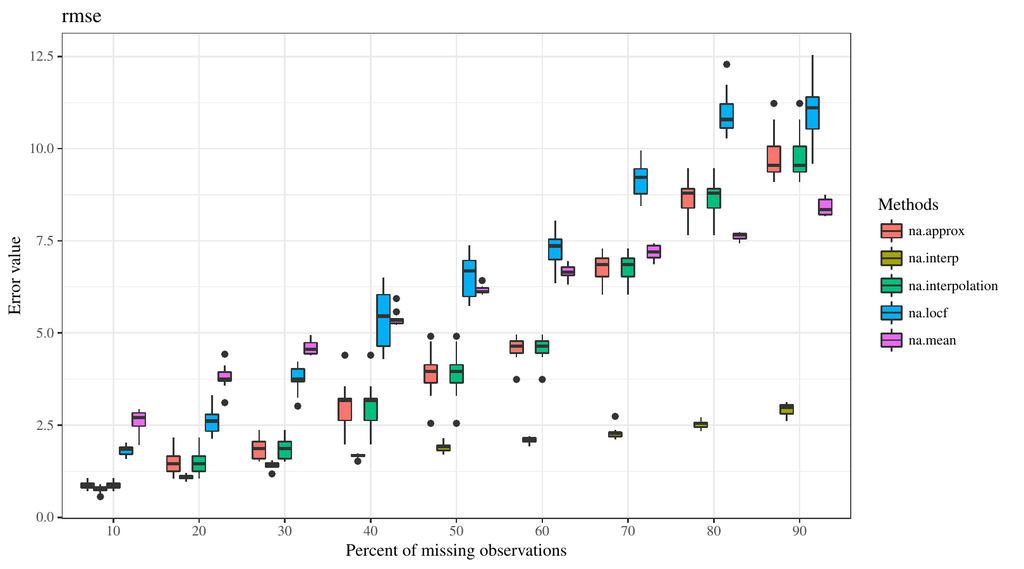

Figure 2: Distribution of error values from the `"errprof"` object for each imputation method and interval of missing observations. The plot is created with `plot_errors()` using the boxplot option.

```r
plot_errors(a)
```

The bar and line options for `plotType` show the average error values for each repetition. Similar information is shown as the `boxplot` option, although the range of error values for each imputation method is not shown (‘line’ option shown in Figure 3).

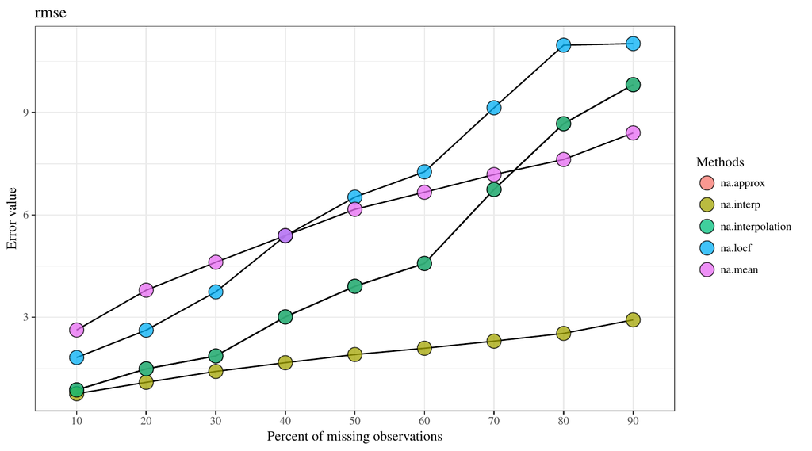

Figure 3: Average error values for each imputation method and interval of missing observations. The `line` option is used for `plot_errors()`.

```r
plot_errors(a, plotType = 'line')
```

## Sampling methods for missing observations

The `impute_errors()` function uses `sample_dat()` to remove observations for imputation from the input dataset. Observations are removed using one of two methods relevant for univariate time series: MCAR and MAR. The MCAR sampling scheme assumes all observations have equal probability of being selected for removal and is appropriate for understanding imputation accuracy with univariate time series that are not serially correlated (Rubin 1976). Conversely, the MAR sampling scheme selects observations in blocks such that the probability of selection for a single observation depends on whether an observation closer in time was also selected (Schafer and Graham 2002). The MAR scheme is appropriate for time series with serial correlation. The `sample_dat()` function has the following syntax:

```r
sample_dat(datin, smps = "mcar", repetition = 10, b = 50, blck = 50, blckper = TRUE,
  plot = FALSE)
```

### `datin`:

Input `"ts"` object or numeric vector, inherited from `dataIn` from `impute_errors()`.

### `smps, repetition, blck, blckper`:

Arguments that are inherited as is from `impute_errors()` indicating the sampling type (`smps`), number of repetitions for each missing data type (`repetition`), block size (`blck`), and block type as percentage or count (`blckper`).

### `b`:

Numeric indicating the total amount of missing data as a percentage to remove from the complete time series. The arguments `missPercentFrom`, `missPercentTo`, and `interval` from `impute_errors()` define `b` for each simulation of missing observations with `sample_dat()`. For example, missing data will be simulated with `sample_dat()` for percentages of the total sample size as `b = 10, 20, ..., 90` if `missPercentFrom = 10`, `missPercentTo = 90`, and `interval = 10` for `impute_errors()`.

### `plot`:

Logical indicating if a plot is returned that shows one repetition of the sampling scheme defined by the arguments (Figure 4).

The MCAR sampling scheme is used if `smps = ’mcar’`, where the only relevant arguments are `missPercentFrom`, `missPercentTo`, and `interval` from `impute_errors()` for the missing data. The amount of data to remove for each interval is passed to the `b` argument in `sample_dat()`. Alternatively, the MAR sampling scheme requires additional arguments to control the block size for removing data in continuous chunks, in addition to the total amount of data to remove defined by `b`. The block size argument, `blck`, can be given as a percentage or as number of observations in sequence. The type of block size passed to `blck` is controlled by `blckper`, where `blckper = TRUE` indicates a percentage and `FALSE` indicates a count for `blck`. For example, if the total sample size of the dataset is 1000, `b = 50`, `blck = 20`, and `blckper = TRUE` means half the dataset is removed (`b = 50`, 500 observations) and each block will have 100 observations (20% of 500). For both percentages and counts, the blocks are automatically selected until the total amount of missing data is equal to that specified by `b`. Final blocks may be truncated to make the total amount of missing observations equal to `b`. The starting location of each block is selected at random and overlapping blocks are not uniquely counted for the required sample size given by `b` (i.e., blocks larger than that specified by `blck` may occur of two separate blocks overlap).

The `sample_dat()` function is typically not used independently of `impute_errrors()`, although an optional plotting argument is provided to visualize different sampling schemes for removing data. Figure 4 shows examples of sampling with MCAR and MAR.

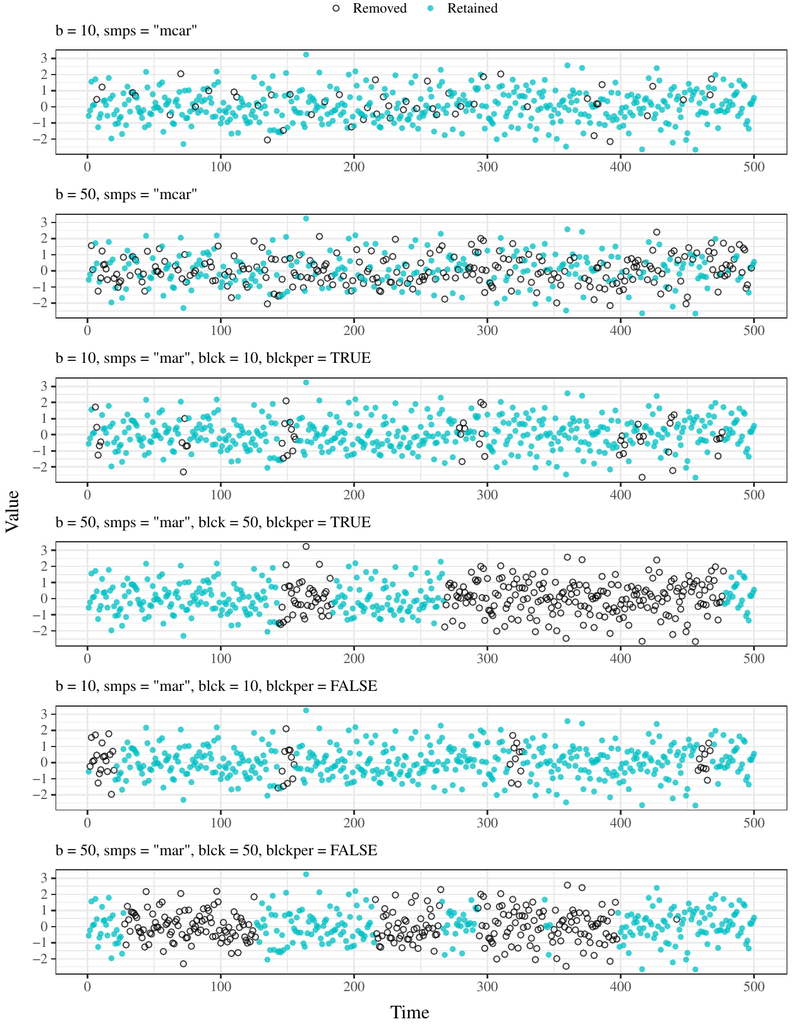

[output not shown]

. Values to be removed and imputed are shown as open circles and the data to be kept are in blue. From top to bottom, sampling is MCAR with 10% missing, MCAR with 50% missing, MAR with 10% missing and block size 10% of total missing, MAR with 50% missing and block size 50% of total missing, MAR with 10% missing and block size of ten observations, and MAR with 50% missing and block size of fifty observations.

## The `plot_impute()` function

The third plotting function available in *imputeTestbench* is `plot_impute()`. This function returns a plot of the imputed values for each imputation method in `impute_errors()` for one repetition of sampling for missing data. The plot shows the results in individual panels for each method with the points colored as retained or imputed (i.e., original data not removed and imputed data that were removed). An optional argument, `showmiss`, can be used to plot the original values as open circles that were removed from the data. The `plot_impute()` function shows results for only one simulation and missing data type (e.g., `smps = ’mcar’` and `b = 50`). Although the plot from `plot_errors()` is a more accurate representation of overall performance of each method, `plot_impute()` is useful to better understand how the methods predict values for a sample dataset (Figure 5).

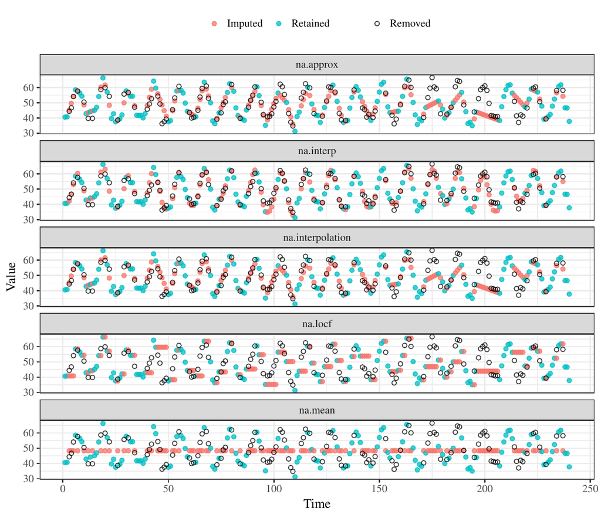

Figure 5: Output from the `plot_impute()` function that shows the data that were retained (blue), removed (open circles), and imputed (red).

```r
plot_impute(dataIn = nottem, showmiss = T)
```

## Including additional arguments

Additional arguments for the imputation functions used by `impute_errors()` can easily be modified. This is useful for changing the default arguments, particularly for the three linear interpolation methods (`na.approach()`, `na.interp()`, `na.interpolation()`). Although these methods are very similar in the default configuration, the amount of flexibility varies considerably. For example, `na.interpolation()` provides spline interpolation as an alternative that is not provided by the other functions. Using each method without modifying the additional arguments is not suggested given that no information is gained by comparing the linear interpolation methods with the default setup.

Accordingly, additional arguments can be passed to any of the imputation methods using the `addl_arg` argument. These additional arguments are passed as a `list` of lists, where the list contains one to many elements that are named by the methods in `methods`. The elements of the list are lists with arguments that are specific to each imputation method. For example, the default imputation function `na.mean()` has an additional `option` argument that specifies the algorithm for missing values, where possible values are `"mean"`, `"median"`, and `"mode"`. This argument can be changed from the default `option = "mean"` with `addl_arg` in `impute_errors()`, as shown below. Arguments to user-supplied imputation functions (below) can be changed similarly.

```r
# changing the option argument for na.mean
impute_errors(dataIn = nottem,
  addl_arg = list(na.mean = list(option = 'mode'))
  )
```

# Adding imputation methods and error metrics

Additional imputation methods saved as an R script can be added to `impute_errors()`. Attention should be given to the format of the user-supplied function shown below. The time series data (as numeric or `"ts"` object) with missing values is required as input and the return value is the input dataset with imputed values, where the input and output objects have the same length. The `impute_errors()` function will not process the data correctly if the format is incorrect. The file path for the R script is supplied as an input string to the `methodPath` argument and the function name is added to the `methods` argument for the `impute_errors()` function.

```r
# function to include with impute_errors
new_imp <- function(In){
  out <- imputeTS::na.random(In)
  out <- as.numeric(out)
  return(out)
}
```

Each of the metrics are called by the `error_functions()` function internally within `impute_errors()`. Additional error metrics are added using an approach similar to that used for adding imputation methods. The following example shows use of the percent change in variance (*PCV*, (Tak, Woo, and Yeo 2016)) as an alternative error metric:

The user-supplied error function must include two arguments as input, the first being a vector of observed values and the second being a vector of imputed missing values equal in length to the first. The function must also return a single value as a summary of the errors or differences. As before, the new error function should be saved as an R script. The file path is added to the `errorPath` argument and the error function name is added as a character string to the `errorParameter` argument for `impute_errors()`.

```r
# error metric to include with impute_errors
pcv <- function(dataIn, imputed)
{
  d <- (var(imputed) - var(dataIn)) *
    100/ var(imputed)
  d <- as.numeric(d)
  return(d)
}
```

# Demonstration of *imputeTestbench*

This example demonstrates how *imputeTestbench* can be used to compare imputation methods, and more importantly, how it can be used to better understand the effects of time series characteristics on prediction accuracies. The objective of the comparison is to relate prediction accuracies of each method to the time series characteristics of each dataset, including a description of how the amount and type of missing data influence the results. Three univariate datasets with different characteristics are evaluated (Figure 6). The first dataset, `nrm`, is a sample of 100 random observations from a standard normal distribution to simulate a dataset with no temporal correlation. The second dataset, `austres`, is a `"ts"` object of Australian population in thousands, measured quarterly from 1971 to 1994 (Brockwell and Davis 1996). This dataset includes a simple correlation structure with minimal random noise. The final dataset is `nottem` as described above. This dataset is characterized by a cyclical or repeating seasonal component. Lagged correlations show the differences in the temporal dependencies between the datasets (Figure 6).

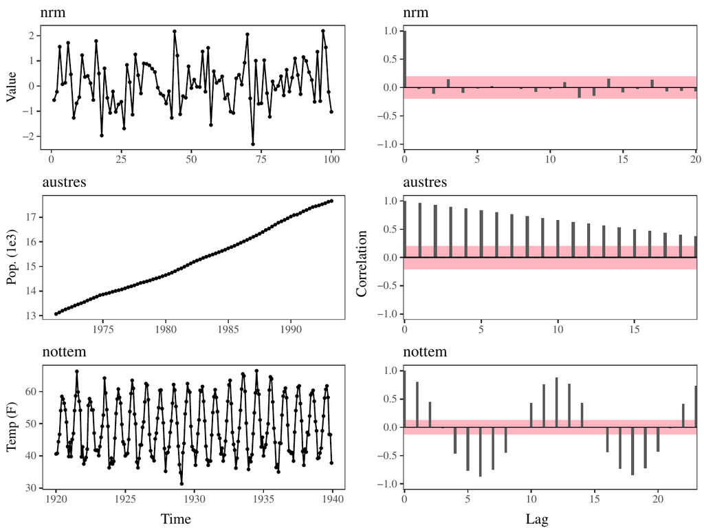

Figure 6: Three datasets used to demonstrate application of *imputeTestbench*. The top dataset, `nrm`, was created with random samples from a normal distribution. The bottom two datasets are `austres` and `nottem` from the *datasets* package. Each dataset has different temporal correlation structures shown at different lags (right column). The light red shading indicates a threshold beyond which correlations are significant ($\alpha = 0.05$).

Each dataset was evaluated by simulating missing observations from 10% to 90% of the complete data using MCAR (`smps = ’mcar’`) and MAR (`smps = ’mar’`) sampling. The size of each chunk (`blck` argument) for MAR sampling was evaluated at 20% and 100% of the total percentage of missing observations to evaluate an effect of chunk size (small chunks to one large chunk) on imputation accuracy. As such, the analysis evaluated imputation accuracy between the default methods as affected by dataset type (`nrm` - no correlation structure, `austres` - simple correlation, `nottem` - seasonal correlation) and characteristics of the missing observations (MAR, MCAR, varying amounts of missing data and chunk sizes). All comparisons used the *MAPE* metric to evaluate imputation errors given scale differences between the datasets. The following code demonstrates the analysis setup.

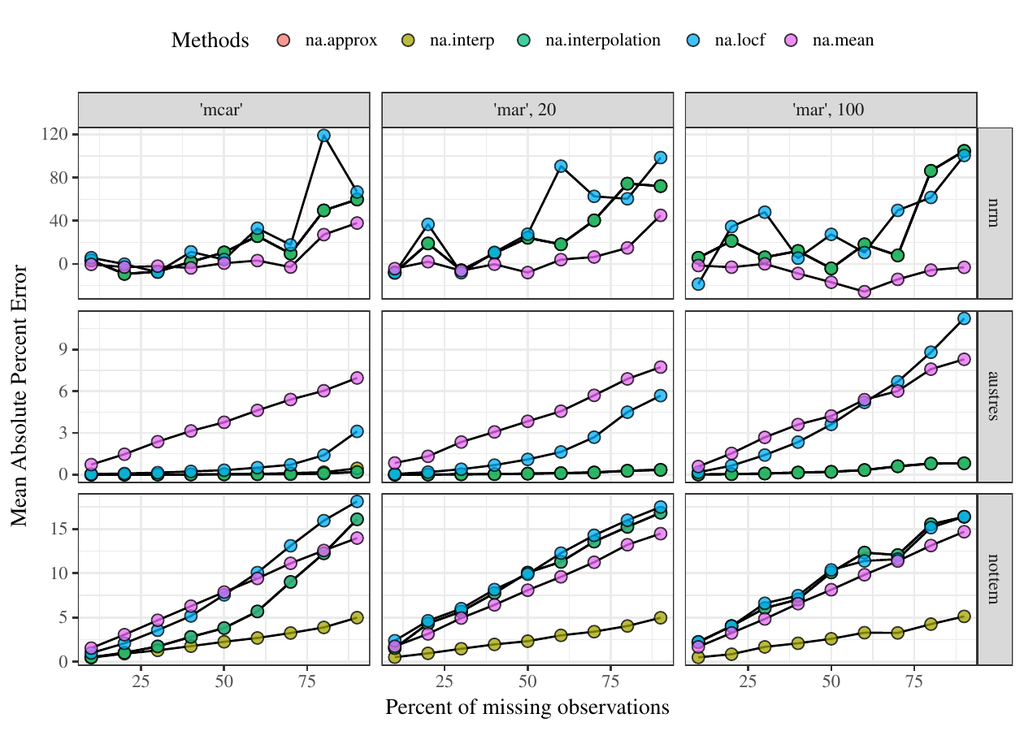

Figure 7: Comparisons of prediction errors for three datasets with different temporal correlation structures (see Figure 6). Missing observations were simulated from the complete datasets as MCAR and MAR with missing chunks of different sizes from 20% and 100% of the total. The total percentage of missing observations from the complete datasets varied from 10% to 90%.

```r
# load packages, set seed
library(tidyverse)
library(imputeTestbench)
set.seed(123)

# create nested list of datasets
dats <- list(
  nrm = rnorm(100),
  aust = austres,
  nott = nottem
  ) %>%
  enframe('nms', 'dataIn')

# create parameters to vary with imputeTestbench
prms <- crossing(
  smps = c('mcar', 'mar'),
  blck = c(20, 100),
  nms = dats$nms
  ) %>%
  mutate( # blck does not matter for mcar
    blck = ifelse(smps %in% 'mcar', NA, blck)
  ) %>%
  unique

# join parameters with data
# map parameter and data to impute_errors
ests <- prms %>%
  left_join(dats, by = 'nms') %>%
  mutate(
    est = pmap(
      list(smps = smps, blck = blck, dataIn = dataIn),
      .f = impute_errors,
      errorParameter = 'mape'
      )
    )
```

The prediction errors varied considerably between the datasets, imputation method, and type of simulation for missing observations (Figure 7). As expected, the type of simulation (MCAR and MAR with different chunk sizes) did not have a noticeable influence on prediction accuracy for the normally distributed dataset with no correlation structure (`nrm`). This dataset is described by only two parameters (mean and standard deviation) and the observations are completely independent such that imputation accuracy was similar for both MCAR and MAR sampling, although accuracy decreased with the addition of missing observations which is not unexpected. The `na.mean()` function generally outperformed the other imputation methods that incorporate some level of information about the relationship between observations. The `nrm` dataset has observations that are not correlated and the use of imputation methods that leverage temporal dependence in the input dataset is expected to induce bias in the imputation, as shown by larger errors.

By comparison, the prediction errors for the `austres` and `nottem` datasets differed in both the type of simulation for missing observations and the imputation method. For `austres`, linear interpolations consistently produced imputations with the least error and each of the three linear interpolation methods (`na.approx()`, `na.interp()`, `na.interpolation()`) performed equally well regardless of simulation type for missing data. This result is not surprising given that `austres` can be described as a monotonic linear increase with minimal variation. That is, imputing a straight line between observations reproduces the original dataset with high accuracy. However, relative prediction accuracies between methods were affected by the type of simulation for removing observations. Imputations with `na.locf()` method had increasing error with increasing size of the missing chunk and errors exceeded `na.mean()` for large chunk sizes and high percentages of missing data (i.e., > 60% missing as one large chunk). These results can be explained by viewing sample imputations with `plot_impute()` (Figure (8). As in Figure 7, the `na.mean()` function performs poorly for most scenarios because it does not capture the linear increase through time. However, the `na.locf()` and `na.approx()` functions perform equally well for small percentages of missing data but error values diverge for larger percentages. Errors for `na.locf()` exceed those for `na.mean()` when large chunks are removed given that the latter produces less biased estimates, although the method performs poorly overall.

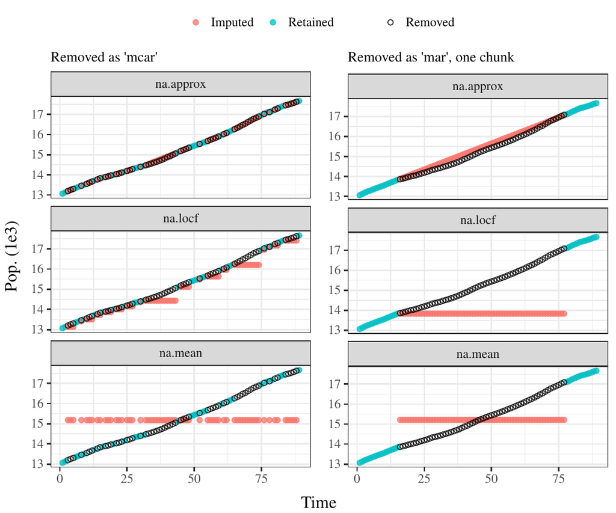

Figure 8: An example from `plot_impute()` of imputed values for the austres dataset using `na.approx`, `na.locf`, and `na.mean`. Seventy percent of observations were removed for each dataset. The left column shows the observations removed using MCAR and the right shows the observations removed using MAR.

Finally, imputations of the `nottem` dataset had similar prediction errors independent of how the data were removed, although the imputation methods varied considerably. Specifically, the `na.interp()` function consistently had lower prediction errors for all percentages of missing observations. Interestingly, the `na.approx()` and `na.interpolation()` functions did not have similar performance as `na.interp()`, although all three methods are similarly documented as linear interpolations. Examples in Figure 5 demonstrate differences in the imputations between the three methods. Both `na.approx()` and `na.interpolation()` do not describe the seasonal variation in the data that is well-described by `na.interp()`. As noted in the documentation, `na.interp()` optionally performs periodic decomposition for seasonal time series based on characteristics of the input data (Hyndman et al. 2017). This highlights the need to carefully understand the assumptions of each method and that the default behavior between ostensibly similar approaches could vary. Users should be familiar with the help documentation and are advised to make use of the `addl_args` argument in `impute_errors()` to modify the default behavior of the chosen imputation functions. The *imputeTestbench* package provides sufficient flexibility to accommodate differences among methods for each approach evaluated with `impute_errors()`.

# Summary

The applied example demonstrated the value of *imputeTestbench* for informing the use of imputation methods as a necessary step towards more formal time series analysis. For all examples, a complete dataset was used to demonstrate how characteristics of the temporal correlation structure can influence the prediction accuracy. The default imputation methods in the package have different approaches to imputing missing values that vary in the amount of dependence on the correlation structure of input data. As expected, the accuracy of each imputation method varied depending on the dataset and a general conclusion is that users should carefully evaluate the correlation structure and periodic components of actual data as an approach to choosing an imputation method. The *imputeTestbench* package greatly facilitates this preliminary step by simultaneously comparing different methods and considering the type and amount of missing observations. In practice, observational data that contain missing values cannot be used directly with the package because the intent is to evaluate hypothetical scenarios of missing observations with complete data. As such, the sample dataset used with *imputeTestBench* should have characteristics similar to the dataset for which imputation is needed. Our applied example evaluated three time series data with different characteristics and additional comparisons of datasets with more complex temporal dependencies could be helpful towards informing practical applications.

We also demonstrated how the package can be modified to include additional imputation methods or comparison metrics. By default, the package provides a core set of existing imputation methods (`na.approx()`, `na.interp()`, `na.interpolation()`, `na.locf()`, and `na.mean()`), which are simultaneously compared using *RMSE*, *MAE*, or *MAPE* error metrics. These simple methods will likely be sufficient for most users, although we recognize that the comparison of other methods and error metrics will be required in more advanced cases. As such, the package allows users to include additional imputation methods for comparison, which could be particularly useful given the capability of R to interface with other programming languages (e.g, [*Rcpp*](https://CRAN.R-project.org/package=Rcpp) for compiled languages, (Eddelbuettel and François 2011); [*matlabr*](https://CRAN.R-project.org/package=matlabr) for MatLab, (Muschelli 2016)). As such, the simple architecture of *imputeTestbench* to add or remove multiple methods and error metrics makes it a robust and useful tool to evaluate existing and proposed imputation techniques for univariate time series.

# Acknowledgments

We thank the R user community for providing feedback that improved earlier versions of the software. The views expressed in this paper are those of the authors and do not necessarily reflect the views or policies of the U.S. Environmental Protection Agency.

Bokde, Neeraj, and Marcus W. Beck. 2017. *imputeTestbench: Test Bench for the Comparison of Imputation Methods*. https://cran.r-project.org/package=imputeTestbench.

Box, G. E. P., G. M. Jenkins, G. C. Reinsel, and G. M. Ljung. 2015. *Time Series Analysis: Forecasting and Control*. 5th ed. Hoboken, New Jersey: John Wiley & Sons.

Brockwell, P. J., and R. A Davis. 1996. *Introduction to Time Series and Forecasting*. Springer-Verlag.

Donders, A. R. T., G. J. M. G. van der Heijden, T. Stijnen, and K. G. M. Moons. 2006. “Review: A Gentle Introduction to Imputation of Missing Values.” *Journal of Clinical Epidemiology* 59: 1087–91. https://doi.org/10.1016/j.jclinepi.2006.01.014.

Eddelbuettel, Dirk, and Romain François. 2011. “Rcpp: Seamless R and C++ Integration.” *Journal of Statistical Software* 40 (8): 1–18. https://doi.org/10.18637/jss.v040.i08.

Gomez, V., and A. Maravall. 1994. “Estimation, Prediction, and Interpolation for Nonstationary Series with the Kalman Filter.” *Journal of the American Statistical Association* 89 (426): 611–24. https://doi.org/10.1080/01621459.1994.10476786.

Gould, P. G., A. B. Koehler, J. K. Ord, R. D. Snyder, R. J. Hyndman, and F. Vahid-Araghi. 2008. “Forecasting Time Series with Multiple Seasonal Patterns.” *European Journal of Operational Research* 191 (1): 207–22. https://doi.org/10.1016/j.ejor.2007.08.024.

Honaker, J., and G. King. 2010. “What to Do about Missing Values in Time-Series Cross-Section Data.” *American Journal of Political Science* 54 (2): 561–81. https://doi.org/10.1111/j.1540-5907.2010.00447.x.

Hyndman, R. J., M. O’Hara-Wild, C. Bergmeir, S. Razbash, and E. Wang. 2017. *Forecast: Forecasting Functions for Time Series and Linear Models*. http://github.com/robjhyndman/forecast.

Jörnsten, Rebecka, Ming Ouyang, and Hui-Yu Wang. 2007. “A Meta-Data Based Method for DNA Microarray Imputation.” *BMC Bioinformatics* 8 (1): 109. https://doi.org/10.1186/1471-2105-8-109.

Li, Huihui, Changbo Zhao, Fengfeng Shao, Guo-Zheng Li, and Xiao Wang. 2015. “A Hybrid Imputation Approach for Microarray Missing Value Estimation.” *BMC Genomics* 16 (Suppl 9): S1. https://doi.org/10.1186/1471-2164-16-s9-s1.

Mendel, J. M. 2000. “Uncertainty, Fuzzy Logic, and Signal Processing.” *Signal Processing* 80 (6): 913–33. https://doi.org/10.1016/s0165-1684(00)00011-6.

Moritz, Steffen, and Thomas Bartz-Beielstein. 2017. “imputeTS: Time Series Missing Value Imputation in R.” *The R Journal*. https://journal.r-project.org/archive/2017/RJ-2017-009/index.html.

Muschelli, John. 2016. *Matlabr: An Interface for MATLAB Using System Calls*. https://CRAN.R-project.org/package=matlabr.

Nguyen, Cattram D, John B Carlin, and Katherine J Lee. 2013. “Diagnosing Problems with Imputation Models Using the Kolmogorov-Smirnov Test: A Simulation Study.” *BMC Medical Research Methodology* 13 (1): 1. https://doi.org/10.1186/1471-2288-13-144.

Ran, Bin, Huachun Tan, Jianshuai Feng, Ying Liu, and Wuhong Wang. 2015. “Traffic Speed Data Imputation Method Based on Tensor Completion.” *Computational Intelligence and Neuroscience* 2015: 22. https://doi.org/10.1155/2015/364089.

Rubin, D. B. 1976. “Inference and Missing Data.” *Biometrika* 63 (3): 581–92. https://doi.org/10.1093/biomet/63.3.581.

Schafer, J. L. 1997. *Analysis of Incomplete Multivariate Data*. Boca Raton, Florida: Chapman; Hall, CRC.

Schafer, J. L., and J. W. Graham. 2002. “Missing Data: Our View of the State of the Art.” *Psychological Methods* 7 (2): 147–77. https://doi.org/10.1037//1082-989x.7.2.147.

Shumway, R. H., and D. S. Stoffer. 2011. *Time Series Analysis and Its Applications: With r Examples*. 3rd ed. New York, New York: Springer-Verlag.

Tak, Sehyun, Soomin Woo, and Hwasoo Yeo. 2016. “Data-Driven Imputation Method for Traffic Data in Sectional Units of Road Links.” *IEEE Transactions on Intelligent Transportation Systems* 17 (6): 1762–71. https://doi.org/10.1109/tits.2016.2530312.

Wickham, Hadley. 2007. “Reshaping Data with the reshape Package.” *Journal of Statistical Software* 21 (12): 1–20. https://doi.org/10.18637/jss.v021.i12.

———. 2009. *Ggplot2: Elegant Graphics for Data Analysis*. Springer-Verlag. http://ggplot2.org.

———. 2017. *Tidyr: Easily Tidy Data with `spread()` and `gather()` Functions*. https://github.com/tidyverse/tidyr.

Wickham, Hadley, and Romain Francois. 2016. *Dplyr: A Grammar of Data Manipulation*. https://CRAN.R-project.org/package=dplyr.

Yozgatligil, C., S. Aslan, C. Iyigun, and I. Batmaz. 2013. “Comparison of Missing Value Imputation Methods in Time Series: The Case of Turkish Meteorological Data.” *Theoretical and Applied Climatology* 112 (1-2): 143–67. https://doi.org/10.1007/s00704-012-0723-x.

Zeileis, Achim, and Gabor Grothendieck. 2005. “Zoo: S3 Infrastructure for Regular and Irregular Time Series.” *Journal of Statistical Software* 14 (6): 1–27. https://doi.org/10.18637/jss.v014.i06.

Zhu, Xiaofeng, Shichao Zhang, Zhi Jin, Zili Zhang, and Zhuoming Xu. 2011. “Missing Value Estimation for Mixed-Attribute Data Sets.” *IEEE Transactions on Knowledge and Data Engineering* 23 (1): 110–21. https://doi.org/10.1109/tkde.2010.99.